# Debata pre debatérov (júlový turnus)

Zpět na rozcestník zpětné vazby | Tento report we Wordu | Data v CSV

## Hodnocení kurzu

Průměrná známka:

| Blok setkání | Průměrná známka |
| --- | --- |
| B | 1.58 |

### Hodnocení po dnech

A a B jsou bloky (A je 9-10:30, B je 11-12:30)

Známky jsou jako ve škole: 1 je nejlepší, 5 nejhorší

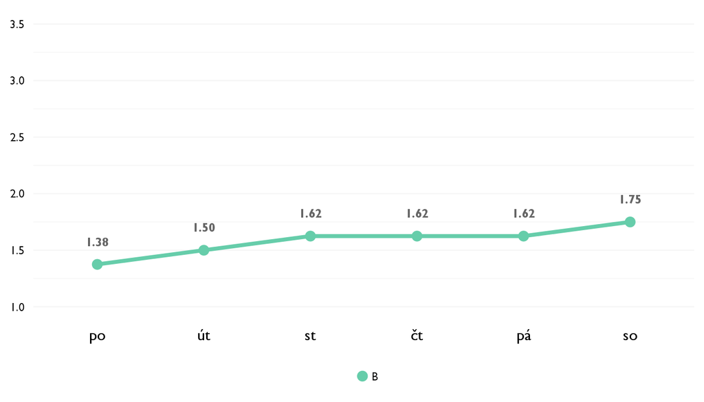

### Co se na kurzu líbilo

- vsetko- cvicenia, lektori, kratka pohybova aktivita na zaciatku, ktora nas prinutila zobudit sa
- Prepojenie teorie a praxy. Velmi vela dobrých príkladov na pochopenie.
- Vysvetlovanie na základe príkladov bolo velmi zrozumitelné.
- To, že všetko čo sme sa v priebehu kurzu naučili, sme si následne aj vyskúšali v praxi.
- Pristup lekotorv, vysoka interakcia
- Skvela teoria
- Naučil som sa nové sposoby tvorenia caseov, argumentov, tvrdení, refutovanie a podobone. A samozrejme ma bavila ta interaktivita.
- Líbila se mi sposta různých užitečných pokročilých debatních technik a jejich srozumitelné vysvětlování.

### Co na kurzu změnit

- neviem mozno viac debat
- Viac debatovania resp. civičení na trénovanie rečí/krosov.
- Nmám čo vytknúť.
- Možno by sa malo počítať s tým, že na Discoveri nemáme príliš veľa voľného času nazvyš a je dosť ťažké si pripraviť case na nasledujúcu hodinu.
- Urcite nic
- Viac debát, tak najlepšie 1 debata za 2 dni aby sme mohli nove znalosti hned skusit aplikovat.
- Možná trochu víc procvičování v podobě samorné debaty.

## Hodnocení lektora

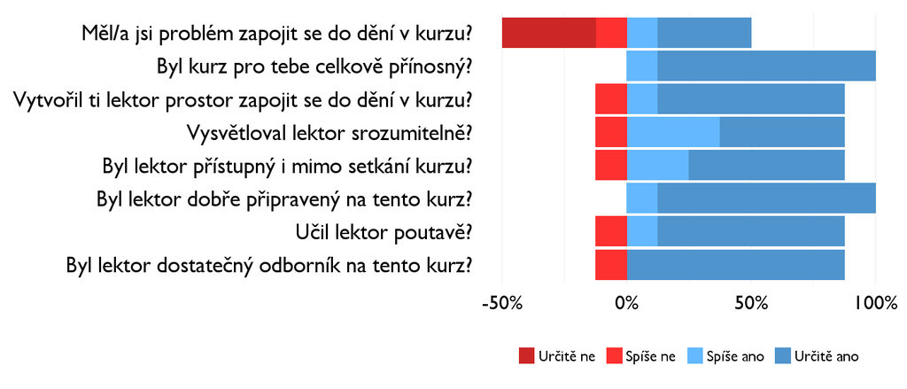

### Komentáře k lektorovi

- ste super
- Trochu viac by som kontroloval kam diskusia smeruje a zastavil pripadne nepodstatnu alebo od temy smerujucu diskusiu.
- Velmi jasne uili.
- (Y)

## Náročnost kurzu

### **Jak hodnotíš náročnost…**

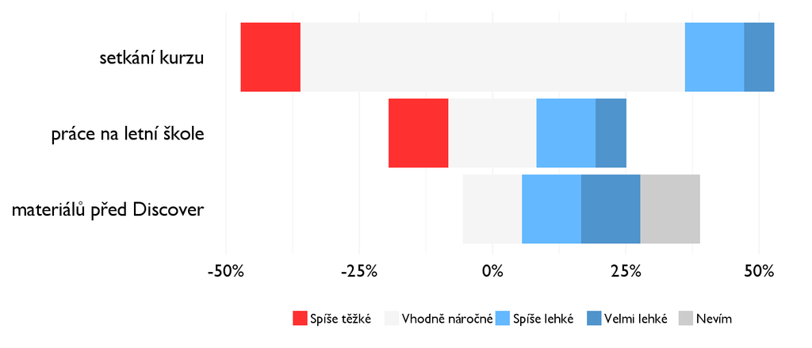

## Didaktika

Na některé otázky jsme se na augustovém turnuse neptali - tam uvidíte nadpis bez grafu.

### Jak lektor učí a měl by to změnit?

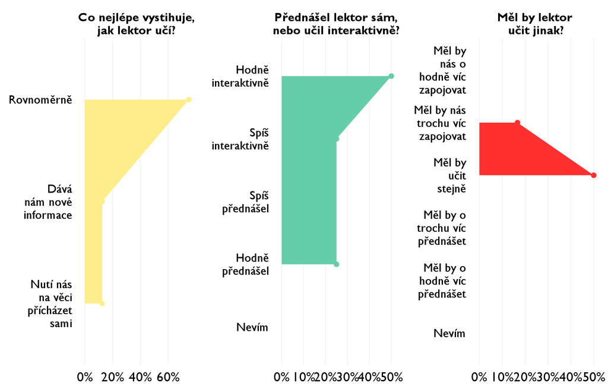

### Jak se studentům nejlépe učí?

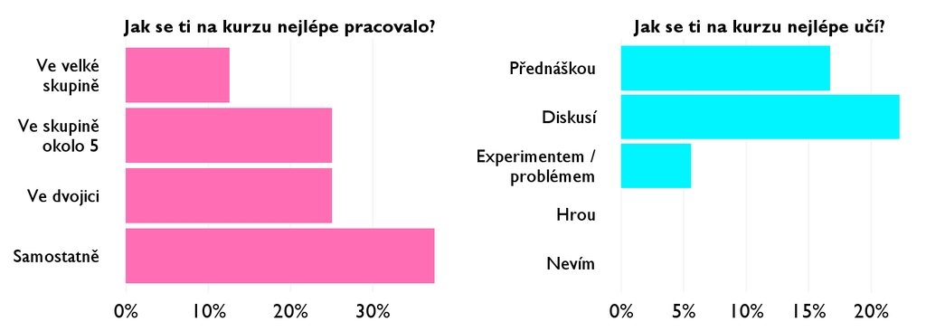

## Ovlivnil tě kurz nějak?

**Pokud ano, jak? Pokud ne, proč ne?**

- ano, naucila som sa ako ucit debaterov v mojom klube
- Zlepšil mi porozumenie o debate. Ukazal nove možnosti a debatné techniky.
- Nové info využijem v debatách.
- Určite ma veľa nového o debate naučil a to mi v budúcnosti dúfam veľmi pomôže.
- Ziskal som nove poznatky a sposoby ako ich predavat dalej
- Pomohol mi pri rozhodnutiach
- Ano, naučil ma už vyššie spomenuté.
- Pomohl mi se zdokonalit v debatě.